# An Analysis on Disproportional Incarceration in the US

Justin Dong

2022-11-01

## Abstract

The United States prison system is one of the most prominent tools that plays a part in the oppression of people of color. This website focuses on the disproportionate imprisonment rate of the African American community in particular and compares it to the imprisonment rate of White people.

## Introduction

This website uses data gathered by the Vera Institute, an organization dedicated to fighting mass incarcerations and the criminalization of marginalized communities. The dataset used contains information regarding general population sizes and prison population sizes with a variety of demographic specific data observations such as race and gender populations. This data is important, as it provides us with data that can challenge the *structural domain* in the matrix of oppression. The prison system has long been a way for governmental authorities to distrupt and oppress minority communities while favoring white cisgendered men.

In this report, the structural domain of oppression will be challenged through a thorough analysis into the data collected by the Vera Institute. I will be demonstrating the disproportional imprisonment of the African American community and compare it to the imprisonment rate of white people. This report impacts the following communities:

- *Direct Shareholder:* The primary group this information impacts are groups with impact on policy, such as lobbyists or politicians. This data shows potential points of inequality with the US prison system, and aims to address it by exposing it to people who can make a change.
- *Indirect Shareholder:* The secondary group this information impacts would be all citizens of the United States, as both general population data and prison inmate population data are used in this report.

## Data Summary

The dataset I am using for this summary contains a wealthy amount of information - the following are some key metrics I have analyzed from the data to provide a general overview of the patterns of inequality this report hopes to hone in on.

## Growth of the US Prison Population

Is mass incarceration still used today? The following chart is a barchart visualizing general prison population growth rate.

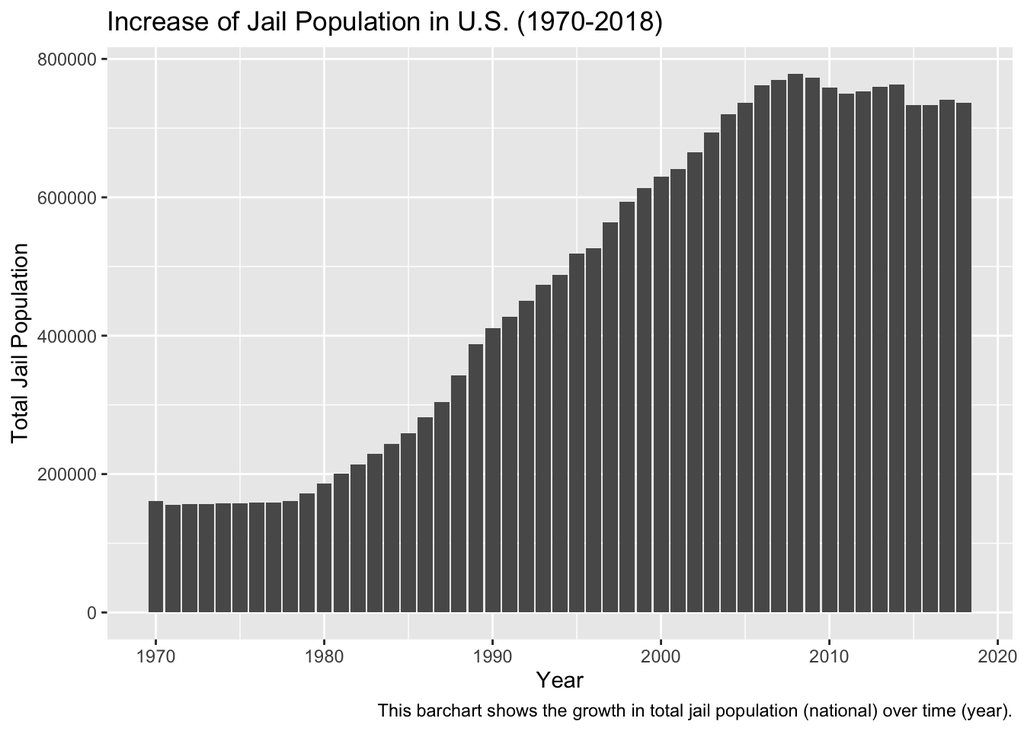

In the barchart, we can see an alarming trend - the amount of inmates has more than quadrupled since 1970. Although we have been seeing a recent decline, the growth in jail population shows that mass incarceration is being used more prominently as of recently.

## Growth of Prison Population by State

How does prison population growth look like in different states? The following chart is a line graph visualizing jail population growth rate in a small sample of states. The states included are Alabama, California, New York, Oregon, and Washington.

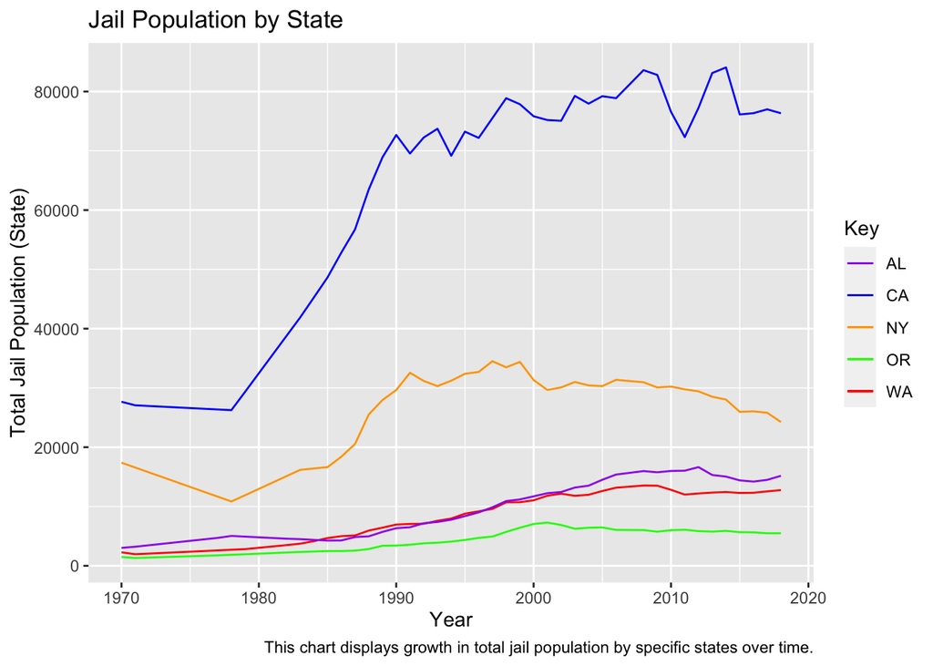

In the graph above, prison population growth rates for particular states of varying political affiliation are shown. While all of the states shown have experienced a general increase in inmate population, California has shot up the most. This may be a reflection of policy, population growth, or more unconsidered factors. Aside from California, the other chosen states have shown similar less aggressive growth rates over the years.

## Population Proportion and Inmate Proportion by Race

Are certain communities imprisoned at higher rates than others? The following charts show the disproportionate rate at which black individuals are imprisoned as compared to white individuals.

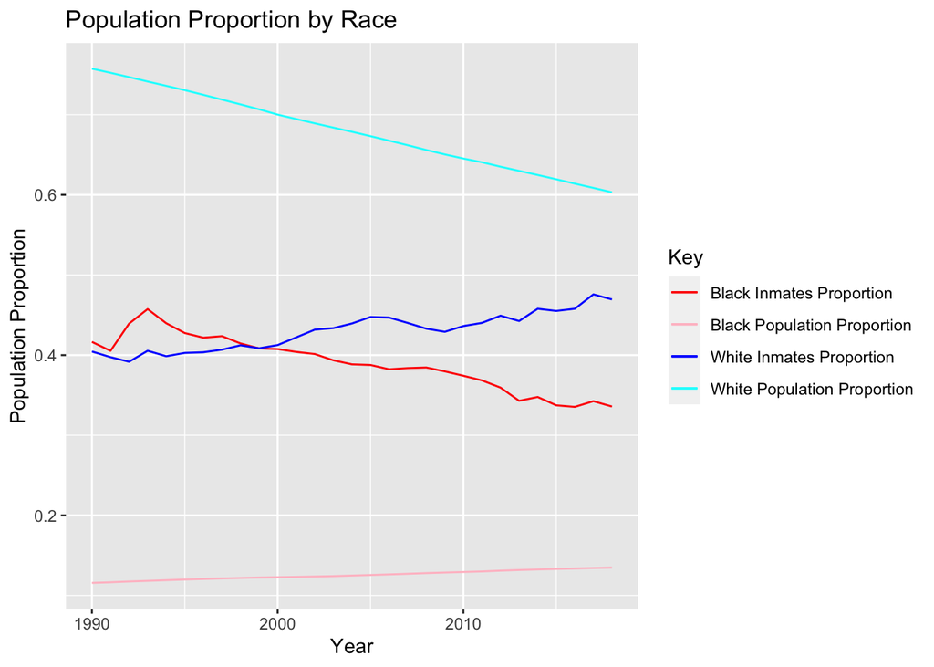

The graph above shows black inmate proportion, white inmate proportion, black population proportion, and white population proportion over the years. One noticeable trend is that while the white population proportion is much higher than the black population proportion over the years, the rate at which black inmates are imprisoned is much higher. The following graph provides a better visualization of this.

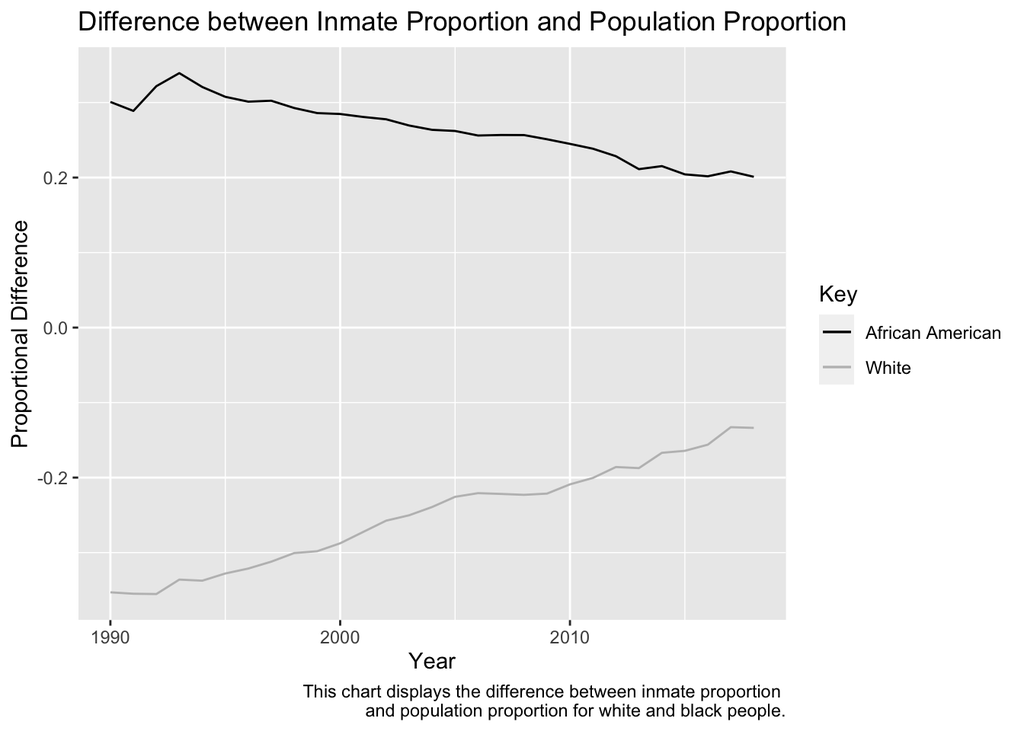

## Map of Inmate/Population Proportion Differences Through Time

Which states have taken steps to mitigate the disproportional representation of black inmates? The following map of the United States shows the increase or decrease in the proportional gap of black and white prison population proportions compared to black and white population size.

[figure not shown]